# Storm Data Analysis

Max Wensel

Saturday, January 24, 2015

Synopsis: This is an R markdown document meant to edify and explain the thought process and code that went into creating a functional data analysis of storm data, as per the data provided by the coursera course reproducible research. This document shows the process that went into cleaning the data before presentation as well as the final results. The analysis proceeded by loading the csv data, then summing fatalities grouped by event type with the plyr package. Event types were then consolidated, and the output shown as a bar graph.

The first step in this code is to load the data, which I have renamed in my working directory as stormdat.csv.The resulting object is saved as “data”. Subsequently, the header and structure of the data are also shown.

Data Processing:

```r
data<-read.csv("stormdat.csv")
head(data)
```

```
##   STATE__           BGN_DATE BGN_TIME TIME_ZONE COUNTY COUNTYNAME STATE
## 1       1  4/18/1950 0:00:00     0130       CST     97     MOBILE    AL
## 2       1  4/18/1950 0:00:00     0145       CST      3    BALDWIN    AL
## 3       1  2/20/1951 0:00:00     1600       CST     57    FAYETTE    AL
## 4       1   6/8/1951 0:00:00     0900       CST     89    MADISON    AL
## 5       1 11/15/1951 0:00:00     1500       CST     43    CULLMAN    AL
## 6       1 11/15/1951 0:00:00     2000       CST     77 LAUDERDALE    AL
##    EVTYPE BGN_RANGE BGN_AZI BGN_LOCATI END_DATE END_TIME COUNTY_END
## 1 TORNADO         0                                               0
## 2 TORNADO         0                                               0
## 3 TORNADO         0                                               0
## 4 TORNADO         0                                               0
## 5 TORNADO         0                                               0
## 6 TORNADO         0                                               0
##   COUNTYENDN END_RANGE END_AZI END_LOCATI LENGTH WIDTH F MAG FATALITIES
```

[output cut: 20 more lines]

```r
str(data)
```

```
## 'data.frame':    902297 obs. of  37 variables:
##  $ STATE__   : num  1 1 1 1 1 1 1 1 1 1 ...
##  $ BGN_DATE  : Factor w/ 16335 levels "1/1/1966 0:00:00",..: 6523 6523 4242 11116 2224 2224 2260 383 3980 3980 ...
##  $ BGN_TIME  : Factor w/ 3608 levels "00:00:00 AM",..: 272 287 2705 1683 2584 3186 242 1683 3186 3186 ...
##  $ TIME_ZONE : Factor w/ 22 levels "ADT","AKS","AST",..: 7 7 7 7 7 7 7 7 7 7 ...
##  $ COUNTY    : num  97 3 57 89 43 77 9 123 125 57 ...
##  $ COUNTYNAME: Factor w/ 29601 levels "","5NM E OF MACKINAC BRIDGE TO PRESQUE ISLE LT MI",..: 13513 1873 4598 10592 4372 10094 1973 23873 24418 4598 ...
##  $ STATE     : Factor w/ 72 levels "AK","AL","AM",..: 2 2 2 2 2 2 2 2 2 2 ...
##  $ EVTYPE    : Factor w/ 985 levels "   HIGH SURF ADVISORY",..: 834 834 834 834 834 834 834 834 834 834 ...
##  $ BGN_RANGE : num  0 0 0 0 0 0 0 0 0 0 ...
##  $ BGN_AZI   : Factor w/ 35 levels "","  N"," NW",..: 1 1 1 1 1 1 1 1 1 1 ...
##  $ BGN_LOCATI: Factor w/ 54429 levels "","- 1 N Albion",..: 1 1 1 1 1 1 1 1 1 1 ...
##  $ END_DATE  : Factor w/ 6663 levels "","1/1/1993 0:00:00",..: 1 1 1 1 1 1 1 1 1 1 ...
##  $ END_TIME  : Factor w/ 3647 levels ""," 0900CST",..: 1 1 1 1 1 1 1 1 1 1 ...
##  $ COUNTY_END: num  0 0 0 0 0 0 0 0 0 0 ...
```

[output cut: 23 more lines]

```r
options(rpubs.upload.method = "internal")
```

The next task is to analyze which events are most harmful to population health. An initial step will be reducing the data to those which caused 1 or more fatalities.

```r
data2<-data[ which(data$FATALITIES>=1), ]
head(data2)
```

```
##    STATE__          BGN_DATE BGN_TIME TIME_ZONE COUNTY COUNTYNAME STATE
## 9        1 2/13/1952 0:00:00     2000       CST    125 TUSCALOOSA    AL
## 13       1 2/13/1952 0:00:00     2130       CST     73  JEFFERSON    AL
## 16       1 3/22/1952 0:00:00     1500       CST    103     MORGAN    AL
## 26       1 2/20/1953 0:00:00     1610       CST     33    COLBERT    AL
## 34       1 4/18/1953 0:00:00     1700       CST     81        LEE    AL
## 36       1  5/1/1953 0:00:00     1930       CST     27       CLAY    AL
##     EVTYPE BGN_RANGE BGN_AZI BGN_LOCATI END_DATE END_TIME COUNTY_END
## 9  TORNADO         0                                               0
## 13 TORNADO         0                                               0
## 16 TORNADO         0                                               0
## 26 TORNADO         0                                               0
## 34 TORNADO         0                                               0
## 36 TORNADO         0                                               0
##    COUNTYENDN END_RANGE END_AZI END_LOCATI LENGTH WIDTH F MAG FATALITIES
```

[output cut: 20 more lines]

```r
str(data2)
```

```
## 'data.frame':    6974 obs. of  37 variables:
##  $ STATE__   : num  1 1 1 1 1 1 1 1 1 1 ...
##  $ BGN_DATE  : Factor w/ 16335 levels "1/1/1966 0:00:00",..: 3980 3980 5341 4244 6525 7638 7638 6898 6372 7545 ...
##  $ BGN_TIME  : Factor w/ 3608 levels "00:00:00 AM",..: 3186 3337 2584 2715 2825 3095 3186 1006 2584 1878 ...
##  $ TIME_ZONE : Factor w/ 22 levels "ADT","AKS","AST",..: 7 7 7 7 7 7 7 7 7 7 ...
##  $ COUNTY    : num  125 73 103 33 81 27 23 103 73 103 ...
##  $ COUNTYNAME: Factor w/ 29601 levels "","5NM E OF MACKINAC BRIDGE TO PRESQUE ISLE LT MI",..: 24418 8485 13551 2929 10334 2897 2867 13551 8485 13551 ...
##  $ STATE     : Factor w/ 72 levels "AK","AL","AM",..: 2 2 2 2 2 2 2 2 2 2 ...
##  $ EVTYPE    : Factor w/ 985 levels "   HIGH SURF ADVISORY",..: 834 834 834 834 834 834 834 834 834 834 ...
##  $ BGN_RANGE : num  0 0 0 0 0 0 0 0 0 0 ...
##  $ BGN_AZI   : Factor w/ 35 levels "","  N"," NW",..: 1 1 1 1 1 1 1 1 1 1 ...
##  $ BGN_LOCATI: Factor w/ 54429 levels "","- 1 N Albion",..: 1 1 1 1 1 1 1 1 1 1 ...
##  $ END_DATE  : Factor w/ 6663 levels "","1/1/1993 0:00:00",..: 1 1 1 1 1 1 1 1 1 1 ...
##  $ END_TIME  : Factor w/ 3647 levels ""," 0900CST",..: 1 1 1 1 1 1 1 1 1 1 ...
##  $ COUNTY_END: num  0 0 0 0 0 0 0 0 0 0 ...
```

[output cut: 23 more lines]

The new output shows only 6974 observations, down from an initial 902297. This should make the data easier to work with. The next step will be to sum fatalities by event type. This will be accomplished through the use of the plyr package. Exploratory analysis will be done on the resultant data frame.

```r
library(plyr)
data3<-ddply(data2, "EVTYPE", function(df)sum(df$FATALITIES, na.rm=T))
head(data3)
```

```
##         EVTYPE  V1
## 1     AVALANCE   1
## 2    AVALANCHE 224
## 3    BLACK ICE   1
## 4     BLIZZARD 101
## 5 blowing snow   1
## 6 BLOWING SNOW   1
```

```r
str(data3)
```

```
## 'data.frame':    168 obs. of  2 variables:
##  $ EVTYPE: Factor w/ 985 levels "   HIGH SURF ADVISORY",..: 18 19 29 30 42 44 54 56 57 60 ...
##  $ V1    : num  1 224 1 101 1 1 3 2 1 3 ...
```

```r
data3
```

```
##                             EVTYPE   V1
## 1                         AVALANCE    1
## 2                        AVALANCHE  224
## 3                        BLACK ICE    1
## 4                         BLIZZARD  101
## 5                     blowing snow    1
## 6                     BLOWING SNOW    1
## 7                    COASTAL FLOOD    3
## 8                 Coastal Flooding    2
## 9                 COASTAL FLOODING    1
## 10                   COASTAL STORM    3
## 11                    COASTALSTORM    1
## 12                            Cold    3
## 13                            COLD   35
## 14                   COLD AND SNOW   14
```

[output cut: 154 more lines]

The data shows many redundant categories, so aggregating some categories would be beneficial. The process of aggregating every category with at least 1 fatality would be quite time consuming; however, so only categories with double-digit fatalities will be used before aggregation. This should not effect the results very much as major contributors to fatalities are at least in double digits.

```r
data3<-data3[ which(data3$V1>=10), ]
data3
```

```
##                         EVTYPE   V1
## 2                    AVALANCHE  224
## 4                     BLIZZARD  101
## 13                        COLD   35
## 14               COLD AND SNOW   14
## 18             COLD/WIND CHILL   95
## 20                   DENSE FOG   18
## 25                  DUST STORM   22
## 26              EXCESSIVE HEAT 1903
## 30                EXTREME COLD  160
## 31     EXTREME COLD/WIND CHILL  125
## 32                EXTREME HEAT   96
## 33           EXTREME WINDCHILL   17
## 35                 FLASH FLOOD  978
## 36           FLASH FLOOD/FLOOD   14
```

[output cut: 43 more lines]

Aggregation of the remaining categories is now done. Row names are periodically reset to avoid confusion.

```r
data3[3,2]<-data3[3,2]+data3[4,2]+data3[5,2]
data3<-data3[-c(4,5), ]
rownames(data3)<-seq(length=nrow(data3))
data3[6,2]<-data3[6,2]+data3[9,2]+data3[18,2]+data3[19,2]+data3[33,2]+data3[46,2]+data3[47,2]
data3<-data3[-c(9,18,19,33,46,47), ]
rownames(data3)<-seq(length=nrow(data3))
data3[3,2]<-data3[3,2]+data3[7,2]+data3[8,2]+data3[9,2]
data3<-data3[-c(7,8,9),]
rownames(data3)<-seq(length=nrow(data3))
data3[2,2]<-data3[2,2]+data3[15,2]+data3[13,2]+data3[22,2]+data3[43,2]+data3[44,2]+data3[45,2]+data3[46,2]
data3<-data3[-c(15,13,22,43,44,45,46),]
rownames(data3)<-seq(length=nrow(data3))
data3[11,2]<-data3[11,2]+data3[7,2]+data3[8,2]+data3[9,2]+data3[10,2]+data3[14,2]+data3[15,2]+data3[26,2]+data3[27,2]
data3<-data3[-c(7,8,9,10,14,15,26,27),]
rownames(data3)<-seq(length=nrow(data3))
data3[4,2]<-data3[4,2]+data3[8,2]
data3<-data3[-8, ]
rownames(data3)<-seq(length=nrow(data3))
data3[19,2]<-data3[19,2]+data3[9,2]+data3[10,2]+data3[15,2]+data3[16,2]+data3[20,2]+data3[21,2]+data3[23,2]+data3[25,2]+data3[30,2]
data3<-data3[-c(9,10,15,16,20,21,23,25,30), ]
rownames(data3)<-seq(length=nrow(data3))
data3[9,2]<-data3[9,2]+data3[10,2]+data3[17,2]
data3<-data3[-c(10,17),]
rownames(data3)<-seq(length=nrow(data3))
data3[19,2]<-data3[18,2]+data3[19,2]
data3<-data3[-18,]
rownames(data3)<-seq(length=nrow(data3))
data3[12,2]<-data3[12,2]+data3[13,2]
data3<-data3[-13,]
rownames(data3)<-seq(length=nrow(data3))
data3[7,2]<-data3[7,2]+data3[16,2]
data3<-data3[-16, ]
rownames(data3)<-seq(length=nrow(data3))
data3
```

```
##               EVTYPE   V1
## 1          AVALANCHE  224
## 2           BLIZZARD  609
## 3               COLD  446
## 4          DENSE FOG   80
## 5         DUST STORM   22
## 6     EXCESSIVE HEAT 3165
## 7  FLOOD/FLASH FLOOD 1693
## 8         HEAVY RAIN   98
## 9          HURRICANE  183
## 10         LANDSLIDE   38
## 11         LIGHTNING  816
## 12       RIP CURRENT  572
## 13       STRONG WIND 1159
## 14           TORNADO 5633
## 15           TSUNAMI   33
## 16          WILDFIRE   87
```

Results: The data has now been reduced to 16 variables, which can best be seen in a bar graph.

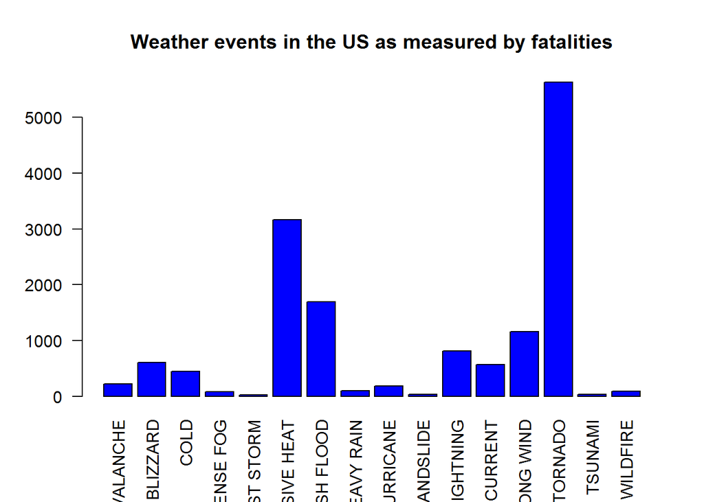

```r
barplot(data3$V1, names.arg=data3$EVTYPE, main="Weather events in the US as measured by fatalities", las=2, col="blue")
```

The graph shows that tornadoes and excessive heat are the two largest causes of fatility in the United States, with floods coming in third.